# Прохождении 2 этапа внешних курсов

Работа на сервере

Киселева Елизавета Александровна

Российский университет дружбы народов, Москва, Россия

17.05.25

# Информация

## Докладчик

- Киселева Елизавета Александровна, НКАбд-02-24
- Студентка факультета физико-математических и естественных наук
- Российский университет дружбы народов
- 1132246735
- https://github.com/liza11223/site-project.git
- https://liza11223.github.io/site-project/
- https://github.com/liza11223/study_2024-2025_os-intro.git

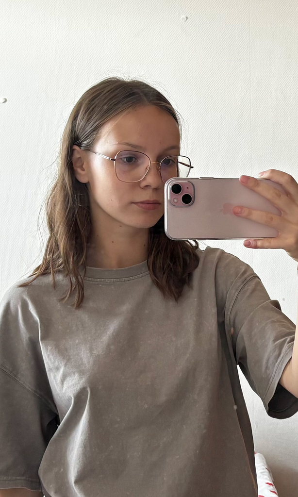

# Цель работы

Ознакомиться с функционалом операционной системы Linux на сервере.

# Задание

Просмотреть видео и на основе полученной информации пройти тестовые задания.

# Теоретическое введение

Linux — семейство Unix-подобных ОС на базе ядра Linux, распространяемых как свободное ПО. Включают утилиты GNU и могут быть как серверными, так и десктопными.

# Этап 2 — Работа на сервере

## Задание 1

[figure not shown]

Удалённый сервер — компьютер в дата-центре, доступный через Интернет. Используется для хостинга сайтов, баз данных, приложений. Протоколы доступа: RDP, VNC, SSH.

## Задание 2

[figure not shown]

Используется только `id_rsa.pub`, так как он является открытым ключом.

## Задание 3

[figure not shown]

Флаг `-r` означает рекурсивную копию каталогов. SCP также следует по символическим ссылкам.

## Задание 4

[figure not shown]

## Задание 5

[figure not shown]

FileZilla — кроссплатформенный FTP-клиент (и сервер). Поддерживает FTP, FTPS, SFTP.

## Задание 6

[figure not shown]

Если GUI не отображается: - Найти терминальную версию - Настроить вывод графики через X11

## Задание 7

[figure not shown]

## Задание 8

[figure not shown]

FastQC поддерживает: - FastQ, SAM/BAM - Gzip-архивы - Цветовое кодирование и Casava

## Задание 9

[figure not shown]

Флаг `--align` запускает множественное выравнивание.

## Задание 10

[figure not shown]

- `Ctrl+C` — завершить процесс
- `Ctrl+Z` — приостановить процесс

## Задание 11–12

[figure not shown]

[figure not shown]

`kill -9` завершает процесс немедленно. Если процесс не перехватывает сигнал — он уничтожается.

## Задание 13

[figure not shown]

Остановленный процесс не реагирует на `kill`, пока не будет продолжен.

## Задание 14–15

[figure not shown]

[figure not shown]

Приостановленный процесс не использует CPU, но занимает память.

## Задание 16

[figure not shown]

`kill` отправляет сигнал на процесс, не на поток. Сигнал будет доставлен одному из активных потоков.

## Задание 17–18

[figure not shown]

[figure not shown]

## Задание 19–20

[figure not shown]

[figure not shown]

Команда `exit` завершает сеанс `tmux`.

## Задание 21–22

[figure not shown]

[figure not shown]

## Задание 23

[figure not shown]

## Задание 24

[figure not shown]

- `Ctrl+b x` — закрыть панель
- Перемещение: `Ctrl+b` + стрелка
- Деление экрана — только в текущем окне `tmux`

# Выводы

- Освежены навыки работы с удалёнными серверами
- Изучены `SSH`, `tmux`, `kill`, `scp`, `FastQC`
- Получен опыт управления процессами и сессиями в Linux

# Список литературы